# Reproducible Research with RMarkdown

Fabian Schroeder

April 12, 2018

## Reproducibility in science

The Oxford Dictionaries Online defines the scientific method as “a method or procedure that has characterized natural science since the 17th century, consisting in systematic observation, measurement, and experiment, and the formulation, testing, and modification of hypotheses”. One of the most important properties that a method of scientific inquiry must satisfy is: reproducibility! The practice of experimental control and reproducibility can have the effect of diminishing the potentially harmful effects of circumstance, and to a degree, personal bias.

According to a 2016 poll of 1,500 scientists reported in the journal Nature, 70% of them had failed to reproduce at least one other scientist’s experiment (50% had failed to reproduce one of their own experiments). This raises the question how to make research more reproducible. According to Prof. Roger Peng, Department of Biostatistics and John Hopkins Bloomberg School of Public Health (Peng 2009) it has to fulfil the following criteria:

- Analytic data must be available
- Analytic code must be available
- Documentation of code and data
- Standard means of distribution

## The data analysis workflow

RMarkdown can aid in increasing the reproduciblity of data driven research, since it

- Maps the entire process of statistical research in one document!
- generates dynamic report, which can be updated automatically if data or analysis change (Friedrich Leisch)

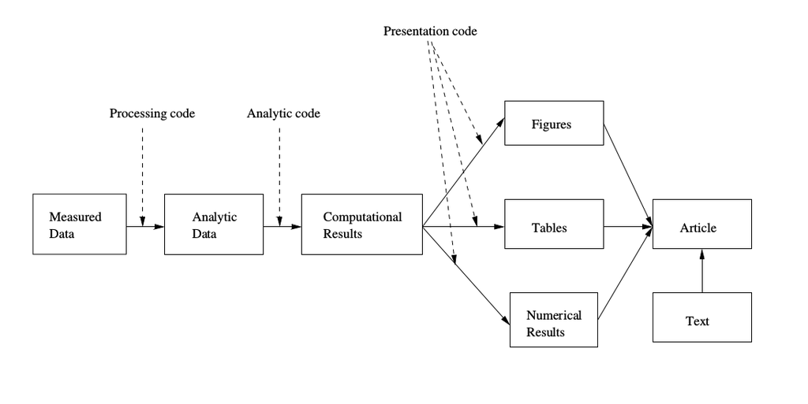

## RMarkdown: How it works.

RMarkdown provides an unified authoring framework for data science, combining your code, its results, and your prose commentary. It, thus, combines,

- Knitr (Xie 2017) (a further development of Sweave (Leisch 2002)) and
- Pandoc Markdown (a slightly revised version of the markup language Markdown (by John Gruber) which can handle multiple output formats and has added new functionalities)
- which has been well integrated into the RStudio IDE.

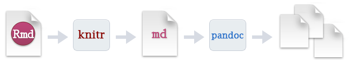

R Markdown documents are fully reproducible and support dozens of output formats, like PDFs, Word files, slideshows, and more.

A good documentation of Rmarkdown can be found under

- http://rmarkdown.rstudio.com
- http://rmarkdown.rstudio.com/gallery.html

Rmarkdown documents consist of three different parts

- a YAML header
- Markdown statements
- knitr R chunks

Let us first have a look at a simple example and then study these three elements separately.

````
---
title: "The Iris Data Set"
author: "Fabian Schroeder"
date: "September 13, 2017"
output: pdf_document
bibliography: bibliography.bib
---

```{r setup, include=FALSE}
library("xtable")
library("stargazer")
data("iris")
```

***

## Description

This famous dataset [@fisher, @anderson] gives the measurements in centimeters of the variables sepal length and width and petal length and width, respectively, for 50 flowers from each of 3 species or iris. The species are *Iris setosa, versicolor*, and *virginica*.

![Illustration of the Variables of the iris data set.](/home/Fabian2/Desktop/StatComp/figures/iris.png)

Iris is a data frame with 150 cases (rows) and 5 variables (columns) named Sepal.Length, Sepal.Width, Petal.Length, Petal.Width, and Species.

```{r summary1, echo = FALSE}
#summary(iris)
```

```{r echo = FALSE, results = "asis"}
options(xtable.comment = FALSE)
xtable::xtable(summary(iris), type = "latex", comment = FALSE, caption = "Summary of the data set")

```

## Scatterplot Matrix

```{r scatterplot, echo = FALSE}
plot(iris)
```

## Logistic Regression Analysis

```{r echo = FALSE, include = FALSE}
iris[['Is.Versicolor']] <- as.numeric(iris[['Species']] == 'versicolor')
iris[['Is.Virginica']] <- as.numeric(iris[['Species']] == 'virginica')
fit.1 <- glm(Is.Versicolor ~ Petal.Length + Sepal.Length, data = iris)
fit.2 <- glm(Is.Virginica ~ Petal.Length + Sepal.Length, data = iris)
#summary(fit)
output <- capture.output(stargazer(fit.1, fit.2, title = 'Regression Results', summary=FALSE, header=FALSE))

```


```{r echo = FALSE, results = 'asis'}
cat(output)
```

## References
````

### Rmarkdown basics

Emphasis

```
*italic*  or _italic_
**bold**   __bold__
```

Headers

```
# 1st Level Header

## 2nd Level Header

### 3rd Level Header
```

Unordered List:

```
*   Bulleted list item 1

*   Item 2

    * Item 2a

    * Item 2b
```

Ordered List

```
1.  Numbered list item 1

1.  Item 2. The numbers are incremented automatically in the output.
```

Links

```
[linked phrase](http://example.com)
```

Images

```
![optional caption text](path/to/img.png)
```

Tables

```
First Header  | Second Header
------------- | -------------
Content Cell  | Content Cell
Content Cell  | Content Cell
```

### knitr R chunks

R code chunks can be used as a means render R output into documents or to simply display code for illustration. Here is a simple R code chunk that will result in both the code and it’s output being included:

````
```{r}
summary(cars)
```
````

To display the output of a code chunk but not the underlying R code, you specify the `echo = FALSE` option:

````
```{r, echo = FALSE}
summary(cars)
```
````

Note that R code chunks can also be used to render plots. To display a plot while omitting the code used to generate the plot you’d do this:

````
```{r, echo = FALSE}
plot(cars)
```
````

To display R code without evaluating it, you specify the `eval = FALSE` chunk option:

````
``{r, eval = FALSE}
summary(cars)
```
````

Table Output

By default data frames and matrixes are output as they would be in the R terminal (in a monospaced font). However, if you prefer that data be displayed with additional formatting you can use the knitr::kable function. For example:

````
```{r, results = 'asis'}
knitr::kable(mtcars)
```
````

Note the use of the `results = 'asis'` chunk option. This is required to ensure that the raw table output isn’t processed furthur by knitr. The kable function includes several options to control the maximum number of digits for numeric columns, alignment, etc (refer to the knitr package documentation for additional details). Caching

If document rendering becomes time consuming due to long computations or plots that are expensive to generate you can use knitr caching to improve performance. The documentation knitr chunk and package options describe how caching works and the cache examples provide additional details.

If you want to enable caching globally for a document you can include a code chunk like this at the top of the document:

````
```{r setup, include = FALSE}
knitr::opts_chunk$set(cache = TRUE)
```
````

If you run into problems with cached output you can always clear the knitr cache by removing the folder named with a _cache suffix within your document’s directory.

The complete list of chunk options can be found at [https://yihui.name/knitr/options/], the developer’s site.

### YAML Header

An overview of the possible settings can be found on the Rmarkdown reference card.

[figure not shown]

[figure not shown]

## References

Leisch, Friedrich. 2002. “Sweave: Dynamic Generation of Statistical Reports Using Literate Data Analysis.” In *Compstat 2002 - Proceedings in Computational Statistics*, edited by Wolfgang Härdle and Bernd Rönz, 575–80. Physica Verlag, Heidelberg. http://www.stat.uni-muenchen.de/~leisch/Sweave.

Peng, Roger D. 2009. “Reproducible Research and Biostatistics.” *Biostatistics* 10 (3): 405–8. doi:10.1093/biostatistics/kxp014.

Xie, Yihui. 2017. *Knitr: A General-Purpose Package for Dynamic Report Generation in R*. https://yihui.name/knitr/.